# DATAMINING PROJECT

Ambrosio Francesca, Santonicola Gerardo, Zappullo Sara

# **UTILIZZO DELL’ANALISI CLUSTER NELLE SERIE STORICHE TEMPORANEE FINANZIARIE**

## Abstract

L’idea del project-work è di dimostrare l’efficacia dell’analisi cluster nelle scelte di investimento di portafogli indicizzati e il contributo che tale analisi può fornire alla tradizionale teoria dei portafogli efficienti di Markovitz.  
Lo schema che porta alla tesi è di tipo deduttivo, costruito step-by-step, a partire dall’analisi di rendimenti di più portafogli azionari, relativi a determinati settori.

Nella prima parte focalizziamo l’attenzione su due portafogli:  
- il primo composto da titoli azionari di società che stanno man mano innovando i loro processi produttivi per un passaggio al “green”;  
- il secondo composto da titoli azionari relativi ai settori della ristorazione e dei trasporti, categorie che hanno subito un duro colpo a causa della pandemia globale.  
Considerati quindi i due portafogli, faremo un’analisi cluster in modo da ottimizzare l’allocazione dei pesi di capitale nei vari asset, al fine di massimizzare il rendimento o minimizzare le perdite. Costruiremo poi sugli stessi portafogli una composizione secondo il modello tradizionale di Markovitz, che verrà successivamente confrontata con la composizione ottenuta dall’asset allocation restituita in precendeza dal clustering.  
Nella terza ed ultima parte, tramite l’ausilio di funzioni elaborate in R, andremo a considerare cinque macrosettori: ristorazione, trasporti, green, farmaceutico e tecnologico, estraendo casualmente un numero di azioni predefinito da ognuno dei settori, costruendo un portafoglio efficiente e ben diversificato secondo la logica di Markowitz e andremo a confrontarne l’ottimalità.

## **Introduzione**

Il 2020 è stato un anno di cambiamenti radicali, l’inizio di una vera e propria fase di transizione che rimarrà nella storia.  
Numerosi disastri ambientali hanno preceduto quel che è secondo gli storici il peggior anno di sempre per l’umanità. Bastano pochi esempi per intuire l’impatto che l’uomo sta avendo sul pianeta Terra, a partire da Chernobyl, passando per i numerosi disastri petroliferi, sino ad arrivare al tanto discusso e temuto cambiamento climatico. Secondo gli studiosi il coronavirus è il primo allarme, la risposta che l’uomo ha avuto dalla natura ad anni di sprechi, inquinamento e invasione rurale.

Nella prima parte di questa analisi andremo proprio a capire quel che è stato l’impatto finanziario del covid, analizzando due portafogli, composti rispettivamente da titoli azionari “green” e titoli “turistici”.  
Nel primo portafoglio troveremo azioni di società che hanno colto le direttive internazionali su quel che è la tutela dell’ambiente, e che in prospettiva daranno un enorme contributo alla riduzione dell’impatto negativo che l’uomo ha sulla natura. Nel secondo portafoglio vedremo come il covid ha impattato su uno dei settori colpiti maggiormente in quella che è considerata la più grande crisi finanziaria del secolo.  
Secondo alcuni analisti, i mercati finanziari hanno subito un collasso più grave della crisi del ’29, della crisi del debito sovrano e dei subprime (2008-2009). Dai risultati ottenuti tramite un’analisi preliminare dei dati e un’analisi cluster con conseguente riallocazione del capitale nei vari asset, trarremo delle conclusioni che ci faranno capire quel che è stato il covid per i mercati finanziari.  
Nella seconda parte, confronteremo l’efficienza dei portafogli ottenuti seguendo il modello media-varianza con l’efficienza degli stessi portafogli le cui allocazioni dei pesi sono state determinate a seguito dell’analisi cluster.  
Inoltre, in una breve appendice andremo a computazionare un portafoglio efficiente genererico con l’ausilio di una funzione scritta in R, che estrarrà casualmente un numero predefinito di titoli azionari da un settore a scelta. Si costruirà un problema di minimo vincolato, risolvendolo con la determinazione del portafoglio che secondo la logica di Markowitz, minimizza il rischio e massimizza il rendimento. Non mancherà il confronto con il corrispettivo portafoglio efficiente ottenuto dall’ordinamento dei pesi tramite clustering.

*Specifiche*: di seguito, le librerie utili a condurre l’indagine.

```r
library(quantmod)
library(xts)
library(rvest)
library(tidyverse)
library(stringr)
library(forcats)
library(lubridate)
library(plotly)
library(dplyr)
library(PerformanceAnalytics)
library(PortfolioAnalytics)
library(dygraphs)
library(rmarkdown)
library(ggplot2)
library(ggiraph)
```

# **Capitolo 1: Tendenze di mercato**

## **1.1** *Analisi preliminare dei dati e calcolo dei rendimenti.*

Il primo passo è creare un dataset di informazioni da cui attingere per le diverse composizioni di portafogli che si andranno a creare.  
Utilizzando funzioni implementate nel pacchetto [quantmod](https://cran.r-project.org/web/packages/quantmod/quantmod.pdf), è possibile estrarre da serie storiche di titoli azionari determinate informazioni di interesse, fino all’ultimo giorno di trading disponibile al momento della rilevazione tramite il pacchetto [PerformanceAnalytics](https://cran.r-project.org/web/packages/PerformanceAnalytics/PerformanceAnalytics.pdf).

In questo caso è stato richiesto di ricevere per ogni ticker inserito, i corrispettivi *adjusted prices* su base giornaliera, nell’arco temporale 02-01-2020 fino all’ultimo giorno disponibile di trading.

*Osservazione*

L’adjusted price (prezzo aggiustato per il rischio) modifica il prezzo di chiusura di un’azione per riflettere il valore dell’azione dopo la contabilizzazione di qualsiasi azione aziendale. Viene spesso utilizzato quando si esaminano i rendimenti storici o si fa un’analisi dettagliata della performance passata.  
Il prezzo di chiusura è il prezzo grezzo, che è solo il valore in contanti dell’ultimo prezzo negoziato prima della chiusura del mercato, mentre l’adjusted price, tiene conto delle azioni societarie, come i frazionamenti azionari, i dividendi e le offerte di diritti.  
I valori delle azioni sono indicati in termini di prezzo di chiusura e “prezzo di chiusura rettificato”.  
Le rettifiche permettono agli investitori di ottenere una registrazione accurata della performance del titolo, e risultano essere particolarmente utili quando si esaminano i rendimenti storici perché dà agli analisti una rappresentazione accurata del valore azionario dell’azienda.

```r
#Costruiamo una function per calcolare i rendimenti dei titoli del nostro portafoglio.

daily_returns <- function(ticker, base_year)
  #INPUT FUNCTION:
  #il ticker corrisponde all'identificativo dell'asset,
  #mentre base_year è l'anno di riferimento per il download dei dati.
  {

  #Tramite la funzione getsymbols di Quantmod ottengo le API dei titoli azionari da YAHOO! Finance
  stock <- getSymbols(ticker, src = "yahoo", auto.assign = FALSE)
  # Rimuoviamo i missing values
  stock <- na.omit(stock)
  # Consideriamo la colonna relativa agli adjusted prices
  stock <- stock[, 6]

  # Facciamo in modo da considerare un orizzonte temporale partendo dall'inizio di un anno base (nel nostro caso 2020) fino all'ultimo giorno di trading disponibile.

  horizon <- paste0(as.character(base_year), "/", as.character(Sys.Date()))
  #paste0 mi concatena i vettori delle date dopo averli resi
  ##di tipo carattere
  stock <- stock[horizon]

  #Calcoliamo i rendimenti (mensili o giornalieri, basta sostituire daily o monthly in period), consideriamo quelli giornalieri tramite la funzione period return di quantmod.
  data <- periodReturn(stock, period = "daily", type = "arithmetic")

  # Facciamo in modo di poter accedere ai dati semplicemente inserendo il Ticker dell'asset (la sigla) e creando così in automatico un vettore colonna.
  assign(ticker, data, envir = .GlobalEnv)
}
```

Supponiamo ora, di avere due investitori, **Mr. Eco** e **Mr. Flight**, che all’inizio del 2020 credevano rispettivamente nella crescita delle quote ambientali e nel boom del settore trasporti/ristorazione. Andiamo ad osservare quali conseguenze hanno riportato i loro portafogli a seguito dello shock finanziario causato dal Covid-19.

## **1.2** *Composizione Green Portfolio* - Mr. Eco

Per la composizione del portafoglio green, sono stati selezionati ben 25 titoli azionari di società relative al settore ambientale; citandone qualcuna abbiamo Tesla, dedita alla produzione di auto elettriche, Nikola, azienda innovatrice nel campo dei veicoli pesanti di trasporto all’idrogeno e SolarEdge, società per la produzione di energia solare.

- GREEN PORTFOLIO

```r
#Comporremo il nostro portafoglio green dai titoli azionari di 25 società che hanno effettuato investimenti per la traslazione al green, e l'indice di riferimento di mercato QCLN come Benchmark.

daily_returns("TSLA", 2020) #Tesla
daily_returns("ALB", 2020) #Albemarle
daily_returns("NKLA", 2020) #NIKOLA
daily_returns("SEDG", 2020) #SolarEdge
daily_returns("ENPH", 2020) #Enphase Energy
daily_returns("NIO", 2020) #Nio inc. ADR
daily_returns("PLUG", 2020) #Plug Power Inc.
daily_returns("CREE", 2020) #Cree Inc.
daily_returns("ON", 2020) #ON Semiconductor Corp
daily_returns("FSLR", 2020) #First Solar
daily_returns("RUN", 2020)#SunRun
daily_returns("NEE", 2020) #NextEra Energy
daily_returns("AY", 2020) #Atlantica
daily_returns("BL", 2020) #Bloom energy corp.
daily_returns("CSIQ", 2020) #Canadian Solar inc.
daily_returns("FCEL", 2020) #FuelCell Energy
daily_returns("NOVA", 2020) #Sunnova
daily_returns("OEZVY", 2020) #Verbund AG
daily_returns("CMI", 2020) # Cummins
daily_returns("VWDRY", 2020) #Vestas Wind System
daily_returns("JKS", 2020) #JinkoSolar Holding
daily_returns("CIG", 2020) #Companhia Energetica de Minas Gerais
daily_returns("DQ", 2020) #Daqo new energy corp.
daily_returns("IBDRY", 2020) #Iberdrola
daily_returns("GCTAY", 2020) #Siemens Gamesa Renewable Energy
daily_returns("QCLN", 2020) #indice di riferimento nei mercati per le aziende che stanno passando al green
```

- I dati vengono uniti in un unico data-frame:

```r
#adesso uniamo i dati in un unico data-frame e rinominiamo le colonne
#utilizziamo merge.xts per unire tutte le variabili relative ai rendimenti in un unico dataframe
green.returns <- merge.xts(TSLA, ALB, NKLA, SEDG, ENPH, NIO, PLUG, CREE, ON, FSLR, RUN, NEE, AY, BL, CSIQ, FCEL, NOVA, OEZVY, CMI, VWDRY, JKS, CIG, DQ, IBDRY, GCTAY, QCLN)
green.returns <-na.omit(green.returns)
#rinominiamo le colonne dei dataframe con le sigle dei ticker
colnames(green.returns) <- c("TSLA", "ALB", "NKLA", "SEDG", "ENPH", "NIO", "PLUG", "CREE", "ON", "FSLR", "RUN", "NEE", "AY", "BL", "CSIQ", "FCEL", "NOVA", "OEZVY", "CMI", "VWDRY", "JKS", "CIG", "DQ", "IBDRY", "GCTAY",  "QCLN")
```

- ottenendo così l’equivalente di una tabella sulle cui colonne sono riportati i rendimenti dei titoli azionari per ogni giorno (righe) di trading.

| NKLA | SEDG | ENPH | NIO | PLUG | CREE | ON | FSLR | RUN |
| --- | --- | --- | --- | --- | --- | --- | --- | --- |
| 0.0000000000 | 0.000000000 | 0.0000000000 | 0.00000000 | 0.000000000 | 0.000000000 | 0.0000000000 | 0.0000000000 | 0.0000000000 |
| -0.0019379845 | 0.005598654 | -0.0017041241 | 0.02956989 | -0.003086420 | -0.019569892 | -0.0147644858 | -0.0038435009 | 0.0130419457 |
| 0.0019417476 | -0.026860716 | 0.0126322631 | -0.03916449 | 0.182662539 | 0.013160759 | -0.0251114206 | -0.0208698351 | 0.0006958942 |
| 0.0009689922 | 0.021680258 | 0.0111260958 | -0.11956522 | -0.002617801 | 0.014072332 | 0.0245118405 | 0.0150456022 | 0.0222531293 |
| 0.0011616651 | 0.023283259 | 0.0336778926 | 0.04629630 | 0.070866142 | 0.009607195 | 0.0064882401 | 0.0005294336 | -0.0040816327 |
| 0.0007735448 | -0.013632930 | 0.0190322581 | 0.02064897 | -0.007352941 | 0.013321992 | 0.0016116438 | 0.0000000000 | 0.0245901639 |
| -0.0019323671 | 0.017325278 | -0.0291231402 | 0.01445087 | 0.022222222 | 0.028589379 | -0.0112631130 | -0.0035273544 | -0.0060000000 |
| 0.0009680542 | -0.013777220 | 0.0039126508 | 0.05413105 | -0.009661836 | 0.017650618 | 0.0301057771 | 0.0166371504 | 0.0221327968 |
| 0.0009671180 | 0.009119082 | -0.0191620650 | 0.01621622 | -0.014634146 | 0.014752831 | 0.0118483807 | 0.0233286912 | 0.0019685039 |
| 0.0000000000 | -0.003941511 | -0.0013245364 | 0.14095745 | 0.039603960 | 0.007465560 | -0.0288837616 | -0.0685607191 | -0.0052390308 |
| 0.0000000000 | -0.008782975 | 0.0222148541 | 0.01864802 | -0.002380952 | 0.018135726 | 0.0060290195 | -0.0149771689 | 0.0928242265 |
| -0.0009661836 | 0.019961081 | 0.0217320791 | 0.06864989 | -0.004773270 | 0.002873051 | -0.0011986016 | -0.0076024476 | 0.0349397590 |
| 0.0009671180 | 0.026539370 | -0.0076190476 | 0.10706638 | 0.035971223 | -0.001145951 | -0.0083999600 | -0.0368086883 | 0.0110594296 |
| 0.0000000000 | 0.008648749 | 0.0115163468 | -0.07350097 | -0.062500000 | -0.004971281 | 0.0004033078 | -0.0192046172 | -0.0299367283 |
| 0.0000000000 | 0.002489434 | 0.0142314670 | 0.02713987 | -0.029629630 | 0.036125999 | 0.0270161301 | 0.0288765619 | 0.0062314540 |
| -0.0009661836 | 0.012875876 | 0.0196445588 | -0.05284553 | -0.007633588 | -0.038204694 | -0.0188456623 | -0.0015378893 | -0.0097315836 |
| 0.0000000000 | -0.126032846 | -0.0840978568 | -0.13948498 | -0.023076923 | -0.021596587 | -0.0532212885 | -0.0279167699 | -0.0273973182 |
| 0.0004835590 | 0.073870140 | 0.0764607988 | 0.04987531 | 0.070866142 | 0.031533266 | 0.0215553677 | 0.0122796390 | 0.0385792407 |
| 0.0004833253 | -0.006288719 | 0.0099255267 | 0.01425178 | -0.009803922 | -0.031524666 | -0.0119983864 | -0.0041087653 | -0.0005895048 |
| -0.0001932367 | 0.004965456 | 0.0285626834 | -0.04449649 | -0.012376238 | -0.075557271 | 0.0025126467 | -0.0035363653 | 0.0312683757 |
| -0.0007730963 | -0.051927920 | -0.0588235856 | -0.07352941 | -0.030075188 | -0.007895838 | -0.0329992050 | -0.0224763205 | -0.0257436499 |
| 0.0009671180 | 0.031882301 | 0.0444161802 | 0.07407407 | -0.005167959 | 0.017853258 | -0.1399568035 | 0.0133118187 | 0.0299471503 |
| 0.0009661836 | 0.067637104 | 0.1208992783 | 0.11083744 | 0.062337662 | 0.079459045 | -0.0045203415 | 0.0483677529 | 0.0404788460 |
| 0.0000000000 | -0.030980401 | 0.0002709485 | -0.02660754 | 0.009779951 | -0.006264761 | 0.0671039354 | 0.0081640406 | 0.0405479452 |
| 0.0000000000 | -0.005073217 | 0.0400975075 | -0.07061503 | 0.029055690 | -0.006698188 | -0.0113475177 | -0.0084745013 | 0.0073722486 |

- Rappresentiamo i rendimenti utilizzando il pacchetto [dygraph](https://cran.r-project.org/web/packages/dygraphs/dygraphs.pdf), utile per rappresentare serie storiche, con un grafico interattivo.

```r
dygraph(green.returns, main = "Green portfolio") %>% ##Selezioniamo il dataset returns creato in precedenza e rinominiamo il grafico
  dyAxis("y", label = "Return", valueRange = c(-0.5, 1.2)) %>% #Definiamo l'intervallo e rinominiamo le ordinate.
  dyRangeSelector(dateWindow = c("2020-01-02", "2021-02-01")) %>% #definiamo l'intervallo temporale.
  dyOptions(colors = RColorBrewer::brewer.pal(4, "Set2")) ##assegniamo un colore diverso ad ogni asset.
```

[interactive chart not shown]

Implementiamo il grafico di correlazioni tra titoli utilizzando il pacchetto [ggplot2](https://cran.r-project.org/web/packages/ggplot2/ggplot2.pdf) e tutta una serie di altre sotto-librerie.  
Il corrplot è uno strumento generale ma comunque intuitivo e utile per avere una visione d’insieme di quelle che sono le possibili influenze finanziarie tra titoli, poichè la forma del legame correlativo tra i titoli viene espresso in base al colore.

```r
#calcoliamo la matrice di correlazione relativa al portafoglio green.
green.correlation <- cor(green.returns)
green.correlation[upper.tri(green.correlation)] <- NA #sostituiamo i valori del triangolo superiore della matrice con dei missing values
green.correlation <- reshape2::melt(green.correlation, na.rm = TRUE) #rimuoviamo i missing values usati in precedenza
colors = c("red", "white", "blue") #assegniamo i colori rispettivamente a correlazione negativa, nulla e positiva.
#creiamo il ggplot sulla matrice di correlazione.
plot1 <- ggplot(green.correlation) +
  geom_tile(aes(Var1, Var2, fill = value), color = "gray")  +
  scale_fill_gradient2(low = colors[1], high = colors[3],
                       mid = colors[2], midpoint = 0, limit = c(-1, 1), space = "Lab",
                       name = "Corr") +
  geom_text(mapping = aes(x = Var1, y = Var2, label = round(value, 1)), size = 2) +
  ggplot2::coord_fixed() +
  theme_minimal() +
  theme(axis.text.x = element_text(angle = 45,
                                   vjust = 1, size = 8, hjust = 1),
        axis.text.y = element_text(size = 8),
        legend.position = 'bottom') +
  guides(fill = FALSE) +
  xlab("") + ylab("")

green.correlation2 <- green.correlation %>%
  mutate(data_id = paste0(Var1, '-', Var2),
         tooltip = paste0(Var1, '-', Var2, ': ', round(value, 2)))
plot2 <- ggplot(green.correlation2) +
  geom_tile_interactive(aes(Var1, Var2, fill = value,
                            tooltip = tooltip
                            ), color = "gray")  +
  scale_fill_gradient2(low = colors[1], high = colors[3],
                       mid = colors[2], midpoint = 0, limit = c(-1, 1), space = "Lab",
                       name = "Corr") +
  geom_text(mapping = aes(x = Var1, y = Var2, label = round(value, 1)), size = 2) +
  ggplot2::coord_fixed() +
  theme_minimal() +
  theme(axis.text.x = element_text(angle = 45,
                                   vjust = 1, size = 8, hjust = 1),
        axis.text.y = element_text(size = 8),
        legend.position = 'bottom') +
  guides(fill = FALSE) +
  xlab("") + ylab("")

girafe(ggobj = plot2)
```

[interactive chart not shown]

```r
#grazie a questa funzione abbiamo ottenuto una mappa di colore interattiva che permette di osservare i valori e la potenza del legame di correlazione tra gli stock del portafoglio.
```

Quello che si ottiene è una matrice di rendimenti simmetrica, il cui colore che indica maggior correlazione è il blu, che non a caso appartiene al ticker rappresentante l’indice di tutte le azioni green. Nikola, con il colore bianco, risulta essere la meno correlata, probabilmente per via della causa legale sostenuta con la SEC, la quale ha accusato il colosso di non essere sufficientemente “green”.

- Equidistribuiamo i pesi all’interno del nostro portafoglio e andiamo a confrontarne l’andamento rispetto al suo indice di mercato.

```r
#adesso supponiamo di investire 1/25 del nostro capitale su ogni portafoglio
wgs <- c(rep(1/25, 25))

portfolio_returns_green <- Return.portfolio(R = green.returns[,1:25], weights = wgs, wealth.index = TRUE)

# Isoliamo il nostro indice di riferimento,che farà da benchmark
benchmark_returns_green <- Return.portfolio(R = green.returns[,26], wealth.index = TRUE)

# uniamo i due
comp_green <- merge.xts(portfolio_returns_green, benchmark_returns_green)
colnames(comp_green) <- c("Green Portfolio", "Benchmark")
```

```r
# Grafico interattivo per confrontare le performance
dygraph(comp_green, main = "Portfolio Green Performance vs. Benchmark") %>%
  dyAxis("y", label = "Amount ($)")
```

[interactive chart not shown]

Dal grafico si evince che il portafoglio è in linea con l’indice relativo alle azioni presenti in esso. Tale risultato non deve stupire, poichè si sta prendendo in esame un portafoglio specifico di un settore confrontato col proprio indice settoriale di mercato, ma non è affatto superfluo poichè ci fornisce evidenze empiriche circa la corretta estrazione dei dati e la loro validità.

## **1.3** *Composizione Travel&Food Portfolio* - Mr. Flight

Allo stesso modo andiamo a comporre il portafoglio di Mr. Flight, importando da [Yahoo!Finance](https://it.finance.yahoo.com/) i dati relativi ad alcuni titoli azionari attivi nella ristorazione, come McDonald’s e Domino’s Pizza Inc., ed altri quotati nell’ambito della logistica e dei trasporti, quali compagnie aeree e navali.  
Dunque stiamo volutamente componendo un portafoglio del tutto avverso alle tendenze di mercato dell’ultimo anno, per verificare l’adattabilità dei modelli.

- FOOD PORTFOLIO

```r
daily_returns("MCD", 2020)  #McDonald's
daily_returns("DPZ", 2020) #Domino's Pizza Inc.
daily_returns("JACK", 2020) #Jack in the box Inc.
daily_returns("LOCO", 2020) #El pollo loco holdings Inc.
daily_returns("YUM", 2020) #Yum! Brands Inc.
daily_returns("CBRL", 2020) #Cracker Barrel Old Country Store Inc.
daily_returns("CMG", 2020) #Chipotle Mexican Grill Inc.
daily_returns("DRI", 2020) #Darden Restaurants Inc.
daily_returns("CAKE", 2020) #Cheesecake Factory Inc.
daily_returns("WEN", 2020) #Wendys Co.
daily_returns("QSR", 2020) #Restaurant Brands International Inc.
daily_returns("MARR.MI",2020)#Indice di mercato della ristorazione.

rest.returns <- merge.xts(MCD, DPZ, JACK, LOCO, YUM, CBRL, CMG, DRI, CAKE, WEN, QSR, MARR.MI)
rest.returns <-na.omit(rest.returns)
colnames(rest.returns) <- c("MCD", "DPZ", "JACK", "LOCO", "YUM", "CBRL", "CMG", "DRI", "CAKE", "WEN", "QSR","MARR.MI")
```

- TRAVEL PORTFOLIO

```r
daily_returns("UNP",2020) #UNION PACIFIC
daily_returns("JBHT",2020) #j.b.HUNT TRANSPORT SERVICES
daily_returns("CCL",2020) #Carnival Corporation & plC
daily_returns("NCLH",2020)#Norwegian Cruise Line Holdings Ltd.
daily_returns("RCL",2020)# Royal Caribbean Group
daily_returns("RYAAY",2020)#Ryanair Holdings plc
daily_returns("LHA.DE",2020) #Deutsche Lufthansa AG
daily_returns("CAL", 2020) #Caleres Inc.
daily_returns("DAL", 2020) #Delta Air Lines Inc.
daily_returns("IHG", 2020) #InterContinental Hotels Group PLC
daily_returns("MAR", 2020) #Marriott International Inc.
daily_returns("EXPE", 2020) #Expedia
daily_returns("DAX",2020) #Indice di riferimento di mercato dei trasporti.

travel.returns <- merge.xts(UNP, JBHT, CCL, NCLH, RCL, RYAAY, LHA.DE, CAL, DAL, IHG, MAR, EXPE, DAX)
travel.returns <-na.omit(travel.returns)
colnames(travel.returns) <- c("UNP", "JBHT", "CCL", "NCLH", "RCL", "RYAAY", "LHA.DE", "CAL", "DAL", "IHG", "MAR","EXPE","DAX")
```

- Sia “trav.rest” (travel&restaurant) il dataframe contenente i rendimenti:

| JBHT | CCL | NCLH | RCL | RYAAY | LHA.DE | CAL | DAL | IHG | MAR |
| --- | --- | --- | --- | --- | --- | --- | --- | --- | --- |
| 0.0000000000 | 0.000000000 | 0.000000000 | 0.0000000000 | 0.000000000 | 0.0000000000 | 0.000000000 | 0.0000000000 | 0.0000000000 | 0.000000000 |
| -0.0041695222 | -0.027674996 | -0.020907767 | -0.0086148621 | -0.017477089 | -0.0653477218 | 0.003387084 | -0.0165989287 | -0.0185480215 | -0.014654446 |
| -0.0173459769 | -0.030266534 | -0.013888872 | -0.0139336447 | -0.009692121 | -0.0160359205 | -0.005907410 | -0.0068894804 | -0.0073822527 | -0.012929556 |
| 0.0230435373 | 0.003100381 | 0.002992993 | -0.0090404544 | 0.017616569 | 0.0016297262 | -0.010186647 | -0.0008671375 | -0.0108582919 | -0.016288834 |
| 0.0094346628 | 0.004739387 | 0.010531841 | 0.0136460580 | 0.008373003 | 0.0113895216 | -0.017152663 | 0.0215239920 | 0.0021052481 | 0.012349838 |
| 0.0022735807 | 0.009023814 | 0.008511395 | 0.0128573414 | 0.009874293 | 0.0398970399 | -0.014834183 | 0.0018692263 | -0.0076530914 | -0.001908180 |
| 0.0004200145 | -0.007113838 | -0.001722391 | -0.0054510150 | 0.068666667 | -0.0213490099 | -0.007528820 | 0.0047490106 | -0.0072583551 | -0.007237995 |
| -0.0048707290 | 0.010440117 | -0.002070376 | -0.0006006024 | -0.014452059 | -0.0199177996 | -0.027220003 | 0.0042201004 | 0.0031987661 | 0.009698082 |
| 0.0041350489 | 0.017220445 | 0.001037379 | -0.0012020481 | -0.009916689 | -0.0109677419 | 0.002752418 | 0.0329467230 | -0.0009109930 | 0.002384092 |
| 0.0004202152 | 0.004580709 | -0.006217634 | -0.0024821016 | -0.016941886 | -0.0006523157 | -0.035224335 | 0.0027664394 | 0.0003039058 | 0.001019457 |
| 0.0060484197 | 0.018041245 | 0.018074400 | 0.0107827630 | 0.008996250 | 0.0003263708 | 0.041725941 | 0.0042194321 | 0.0115466727 | 0.011676878 |
| -0.0424182240 | 0.010710891 | 0.018265619 | 0.0074598017 | -0.003759781 | -0.0048939641 | -0.008192890 | 0.0024239889 | 0.0096124809 | 0.008320917 |
| 0.0102895548 | -0.023314130 | -0.028499597 | -0.0397631243 | -0.018762110 | -0.0337905654 | -0.007342848 | -0.0272448269 | -0.0407616477 | -0.039198677 |
| -0.0134645679 | -0.015979417 | -0.005522002 | -0.0042410907 | 0.018241802 | 0.0020775623 | -0.015256654 | -0.0116009636 | 0.0103908029 | -0.001731713 |
| 0.0192475787 | -0.008620725 | 0.010237723 | 0.0035622089 | -0.017699190 | -0.0044920525 | -0.021126743 | 0.0105634265 | -0.0219493623 | 0.005828649 |
| -0.0067810431 | -0.039029317 | -0.040879439 | -0.0237671521 | -0.019226544 | 0.0013884068 | -0.036450732 | -0.0242243411 | -0.0204018045 | -0.027179945 |
| -0.0077781534 | -0.047348537 | -0.030085960 | -0.0758833245 | -0.025092395 | -0.0433275563 | -0.003982123 | -0.0336676895 | -0.0418134746 | -0.021415479 |
| -0.0169845600 | 0.027170381 | 0.015509601 | 0.0301085752 | 0.003332196 | 0.0144927536 | -0.004997503 | 0.0114375314 | 0.0262497906 | 0.023550794 |
| -0.0082403345 | 0.000000000 | 0.018545455 | 0.0100473106 | 0.003779226 | 0.0121428571 | -0.057759908 | -0.0144397764 | 0.0001628869 | 0.009628314 |
| -0.0022334844 | -0.037634454 | -0.021777954 | -0.0159486727 | 0.004221278 | -0.0098800282 | -0.053837916 | 0.0079434839 | 0.0035836782 | 0.004908390 |
| -0.0335781743 | -0.027262564 | -0.017335785 | -0.0218880281 | -0.016019042 | -0.0142551675 | -0.011267666 | -0.0238177892 | -0.0035708813 | -0.022678073 |
| 0.0232559125 | -0.017918644 | 0.006313854 | -0.0053810225 | 0.062232986 | 0.0166305134 | 0.015954408 | 0.0053821115 | -0.0071672586 | 0.010138462 |
| 0.0258059346 | 0.018947384 | 0.010334029 | 0.0133105157 | 0.012608739 | 0.0327169275 | -0.008973561 | 0.0337259122 | 0.0300245770 | 0.041843406 |

- Sia questo il grafico interrattivo:

[interactive chart not shown]

* Il grado di correlazione dei titoli:

```r
#calcoliamo la matrice di correlazione relativa al portafoglio travel and food.
travfood.correlation <- cor(trav.rest)
travfood.correlation[upper.tri(travfood.correlation)] <- NA #sostituiamo i valori del triangolo superiore della matrice con dei missing values
travfood.correlation <- reshape2::melt(travfood.correlation, na.rm = TRUE) #rimuoviamo i missing values usati in precedenza
colors = c("red", "white", "blue") #assegniamo i colori rispettivamente a correlazione negativa, nulla e positiva.
#creiamo il ggplot sulla matrice di correlazione.
plotfood1 <- ggplot(travfood.correlation) +
  geom_tile(aes(Var1, Var2, fill = value), color = "gray")  +
  scale_fill_gradient2(low = colors[1], high = colors[3],
                       mid = colors[2], midpoint = 0, limit = c(-1, 1), space = "Lab",
                       name = "Corr") +
  geom_text(mapping = aes(x = Var1, y = Var2, label = round(value, 1)), size = 2) +
  ggplot2::coord_fixed() +
  theme_minimal() +
  theme(axis.text.x = element_text(angle = 45,
                                   vjust = 1, size = 8, hjust = 1),
        axis.text.y = element_text(size = 8),
        legend.position = 'bottom') +
  guides(fill = FALSE) +
  xlab("") + ylab("")

travfood.correlation2 <- travfood.correlation %>%
  mutate(data_id = paste0(Var1, '-', Var2),
         tooltip = paste0(Var1, '-', Var2, ': ', round(value, 2)))
plotfood2 <- ggplot(travfood.correlation2) +
  geom_tile_interactive(aes(Var1, Var2, fill = value,
                            tooltip = tooltip
                            ), color = "gray")  +
  scale_fill_gradient2(low = colors[1], high = colors[3],
                       mid = colors[2], midpoint = 0, limit = c(-1, 1), space = "Lab",
                       name = "Corr") +
  geom_text(mapping = aes(x = Var1, y = Var2, label = round(value, 1)), size = 2) +
  ggplot2::coord_fixed() +
  theme_minimal() +
  theme(axis.text.x = element_text(angle = 45,
                                   vjust = 1, size = 8, hjust = 1),
        axis.text.y = element_text(size = 8),
        legend.position = 'bottom') +
  guides(fill = FALSE) +
  xlab("") + ylab("")

girafe(ggobj = plotfood2)
```

[interactive chart not shown]

```r
#grazie a questa funzione abbiamo ottenuto una mappa di colore interattiva che permette di osservare i valori e la potenza del legame di correlazione tra gli stock del portafoglio.
```

- Verifichiamo l’accuratezza dei dati confrontandoli col proprio indice finanziario di appartenenza.

Si suppone anche in questo caso di investire in modo equo il capitale unitario a disposizione sui vari titoli (i primi 23 dell’elenco trav.rest); tali titoli andranno a comporre il portafoglio che verrà poi confrontato con il benchmark.  
In questo caso, avendo investito in due settori diversi, il benchmark è la composizione degli indici del settore di ristorazione (MARR.MI) e del settore logistico (DAX).

```r
#adesso supponiamo di investire 1/23 del nostro capitale su ogni portafoglio
wgs <- c(rep(1/23, 23))

portfolio_returns_tr <- Return.portfolio(R = trav.rest[,1:23], weights = wgs, wealth.index = TRUE)

# Isoliamo il nostro indice di riferimento,che farà da benchmark
benchmark_returns_tr <- Return.portfolio(R = trav.rest[,24:25], wealth.index = TRUE)
benchmark_returns_tr <-na.omit(benchmark_returns_tr)
# uniamo i due
comp_tr <- merge.xts(portfolio_returns_tr, benchmark_returns_tr)
colnames(comp_tr) <- c("Portfolio", "Benchmark")
```

- Osserviamo l’andamento giornaliero dei titoli:

```r
# Grafico interattivo per confrontare le performance
dygraph(comp_tr, main = "Travel&Food Portfolio Performance vs. Benchmark") %>%
  dyAxis("y", label = "Amount ($)") %>%
  dyOptions(colors = RColorBrewer::brewer.pal(4, "Set1"))
```

[interactive chart not shown]

In questo caso il portafoglio risente della diversificazione, seppur minima, e non sempre si riscontra un andamento coerente con il benchmark, ciò tuttavia non deve stupire poichè l’indice di confronto utilizzato è una composizione di due indici di riferimento di settori diversi (logistica e ristorazione).  
Si riesce tuttavia ad avere conferma della correttezza delle funzioni implementate in R e di quanto riflettano il vero: fino ad aprile 2020, primo periodo di lockdown inaspettatamente prolungato, il portafoglio risulta essere al di sotto del benchmark; verso Ottobre 2020 (seconda chiusura) il portafoglio è al di sopra del proprio indice proprio perchè il mercato ha meglio retto la seconda ondata poichè già precedentemente preparato a tale tendenza negativa nei periodi di chiusura.  
In una situazione diametricalmente opposta si trovava Mr. Eco, il cui portafoglio ha superato le aspettative di mercato, proprio per l’interesse riscontrato verso la green-economy e per i benifici che i vari lockdown hanno apportato all’ambiente, come la riduzione dell’effetto serra.

# **CAPITOLO 2 - ANALISI CLUSTER**

Una volta validati i dataset di cui stiamo dispondendo, il passo successivo sarà svolgere su di essi un’analisi cluster, ma prima una breve digressione sulla teoria che supporta tale analisi.

## **2.1** *Teoria analisi cluster*

Il **clustering** o *analisi dei gruppi* (dal termine inglese cluster analysis introdotto da Robert Tryon nel 1939) è una tecnica fondamentale di analisi multivariata dei dati per la selezione e raggruppamento di elementi omogenei in un insieme di dati. L’ampia varietà delle tecniche di clustering si basano su misure relative alla somiglianza tra gli elementi. Nella maggior parte di esse questa similarità, o meglio, dissimilarità, è pensata in termini di distanza in uno spazio multidimensionale. La bontà delle analisi ottenute dagli algoritmi di clustering dipende molto dal modo in cui viene calcolata la distanza.  
Una suddivisione delle tecniche di clustering tiene conto del tipo di algoritmo utilizzato per dividere lo spazio:  
- **Clustering gerarchico**, in cui viene individuato un insieme di raggruppamenti ordinabili secondo livelli crescenti visualizzabili mediante una raffigurazione ad albero (dendogramma). Si parla di gerarchia indicizzata quando a ciascuna ripartizione corrisponde valore numerico rappresentante il livello al quale hanno luogo i raggruppamenti (livello di aggregazione): più l’indice è elevato, più le parti raggruppate sono eterogenee.  
- **Clustering non gerarchico** (detto anche partizionale), in cui per delimitare l’appartenenza ad un gruppo viene utilizzata una distanza da un punto rappresentativo del cluster (ad esempio: centroide), avendo prefissato il numero di classi.  
Le tecniche di analisi gerarchica si possono a loro volta distinguere in:  
- **Metodi aggregativi** o *bottom-up* (dal basso verso l’alto), in cui inizialmente ciascuna unità costituisce un gruppo a sé stante, e poi l’algoritmo provvede a combinare i cluster più vicini fino a giungere ad una situazione in cui tutte le unità appartengono ad un solo gruppo.  
- **Metodi divisivi** o *top-down* (dall’alto verso il basso), secondo questo metodo, all’inizio, tutti gli elementi sono in un unico cluster e poi ad ogni stadio dell’analisi, l’algoritmo inizia a dividere il cluster in tanti cluster di dimensioni inferiori: i gruppi che si formano sono ciascuno un sottoinsieme di un gruppo formato allo stadio precedente fino ad arrivare al caso estremo in cui ogni unità appartiene ad un unico gruppo.  
Per decidere quali cluster devono essere combinati (approccio agglomerativo) o quale cluster deve essere suddiviso (approccio divisivo) è necessario definire una misura di dissimilarità tra cluster.

In riferimento a tecniche di tipo agglomerativo, le partizioni che si ottengono ad ogni step dell’analisi possono essere rappresentate tramite un *dendogramma*. In tale diagramma ad albero, sull’asse delle ascisse vengono indicate le singole unità, mentre sull’asse delle ordinate viene indicato il livello di distanza. Quest’ultimo è descritto sul grafico attraverso una linea orizzontale di congiunzione di due o più rami, i quali corrispondono, invece, ai gruppi di unità.

A seconda della tipologia di distanza tra gruppi utililizzata, ne consegue uno specifico metodo gerarchico agglomerativo:
- Il **metodo del legame semplice**: la distanza tra due cluster è data dalla minore delle distanze tra gli elementi.
$$d(G_1,G_2)= min\ d(X_{1i}X_{2j})$$
- Il **metodo del legame completo**: in cui si assume la distanza tra i due gruppi come la maggiore delle distanze tra gli elementi.
$$d(G_1,G_2)= max\ d(X_{1i}X_{2j})$$
- Il **metodo del legame medio**: tale metodo calcola la distanza tra i due cluster come la media delle distanze tra i singoli elementi dei due gruppi.
$$d(G_1,G_2)= \frac{1}{n_1n_2} \sum_{i=1}^{n_1} \sum_{j=1}^{n_2} \ d(X_{1i}X_{2j})$$
- Il **metodo del centroide**: la distanza tra i due gruppi coincide con la distanza calcolata tra i centroidi, i quali sono definiti come i punti che hanno per coordinate le medie delle coordinate degli elementi dei gruppi.
$$d(G_1,G_2)= d(\bar{X_1}\bar{X_2})$$
Diverse sono le forme di distanze che vengono considerate nella pratica, le principali sono: - *Distanza euclidea*
- *Distanza di manhattan*
- *Distanza di hamming*

La funzione che misura tali distanze semplicemente specificandole in input è *dist*, contenuta nel pacchetto [stats](https://www.rdocumentation.org/packages/stats/versions/3.6.2).

Alla stessa libreria appartiene anche la funzione per il clustering, *hclust*, utilizzata per l’analisi dei dataset dei due investitori, in cui in input dev’essere precisato il tipo di agglomerazione desiderata (single, complete o average).

*Osservazione*

In ambito finanziario, specie quando si lavora su serie storiche, il metodo più utilizzato è l’average linkage.  
Da un punto di vista tecnico, il tipo *single linkage* è stato evitato perchè tende a non visualizzare i cluster che non sono ben separati; mentre il metodo *complete linkage* non è stato scelto poichè considera la distanze massime come elementi della matrice di distanza e quindi non era appropriato in quest’analisi.  
Il metodo *average linkage* tende ad evitare gli estremi dei cluster molto larghi o molto stretti, è il compromesso tra single e complete linkage, e pertanto è stato scelto.

## **2.2** *Analisi Cluster* - Mr. Eco

Effettuiamo ora un’analisi cluster sul dataset “green.returns”, ovvero sui rendimenti relativi alle azioni che compongono il portafoglio green di Mr. Eco.

```r
#trasponiamo la matrice dei rendimenti in modo da calcolare la matrice di distanze in base ai titoli e non alle date, consideriamo saltanto i 25 titoli del portafoglio, quindi le prime 25 colonne della matrice.

green.returns.c <- green.returns[,1:25]
green.returns.t <- t(green.returns.c)
```

- Adesso calcoliamo la distanza di Manhattan:

```r
manatthan <- dist(green.returns.t, method= "manhattan", diag=F, upper=F)

#osservazione: allo stesso modo è possibile calcolare la distanza euclidea
#euclid <- dist(returns.t, method="euclidean", diag= F, upper=F)
```

```r
#cluster gerarchico SLE ed SLM

#hc.returns.SLE <- hclust(euclid, method = "single")
#print(hc.returns.SLE)
#plot(hc.returns.SLE)

#hc.returns.SLM <- hclust(manatthan, method = "single")
#print(hc.returns.SLM)
#plot(hc.returns.SLM)
```

*Il metodo del centroide non cattura bene la situazione che si sta provando a descrivere, probabilmente perchè forma i gruppi in base ai valori attesi delle variabili (nel nostro caso, titoli). Le distanze tra i vari cluster sono definite in termini di distanza tra due vettori-media, ed essendo serie storiche i dati utilizzati in questo project-work, siamo interessati a tutti i rendimenti giornalieri, non solo a quello atteso.*

- Per questi dataset, il tipo di clustering scelto è: Average Linkage con la distanza di Manhattan.

```r
hc.green <- hclust(manatthan, method = "average")
print(hc.green)
```

```
##
## Call:
## hclust(d = manatthan, method = "average")
##
## Cluster method   : average
## Distance         : manhattan
## Number of objects: 25
```

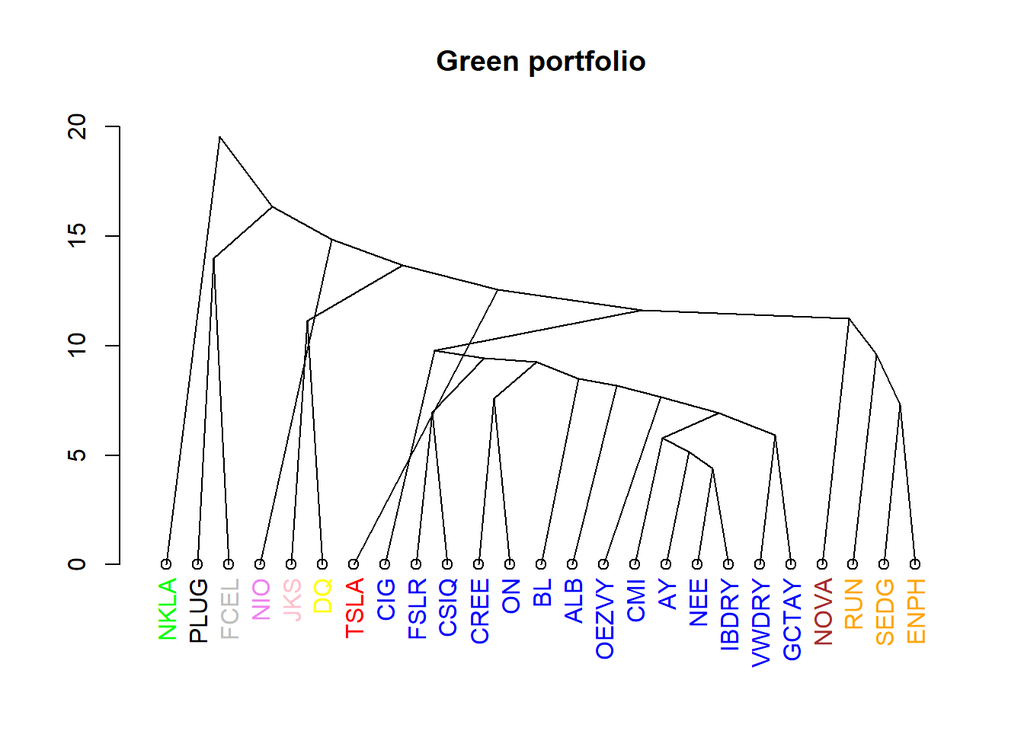

```r
#con la funzione as.dendrogram facciamo in modo di modificare la classe del cluster gerarchico in "dendrogramma".
  hcd <- as.dendrogram(hc.green)
  labelColors = c("red", "blue", "green", "orange", "violet", "black", "gray", "brown", "pink", "yellow") #creiamo il vettore dei colori da assegnare al cluster
cluster.green <- cutree(hc.green, 10) #scegliamo il numero dei cluster
  colorsLabel <- function(n) {
  if (is.leaf(n)) { #is.leaf individua tramite i nodi del dendrogramma un cluster
    a <- attributes(n) #creiamo un vettore vuoto
    labCol <- labelColors[cluster.green[which(names(cluster.green) == a$label)]]
    attr(n, "nodePar") <- c(a$nodePar, lab.col = labCol) #attribuiamo ad n un colore in base ai nodi (cluster)
  }
  n
  } #con questa funzione quindi assegniamo un colore dal vettore labelColors ad ogni cluster.

  clusDendro = dendrapply(hcd, colorsLabel) #con dendrapply quindi applichiamo all' oggetto di classe "dendrogram" un colore in base ai cluster tramite la funzione colLab creata in precedenza, che assegna un colore ad ogni livello

  plot(clusDendro, main = "Green portfolio", type = "triangle")
```

- Redistribuiamo i pesi seguendo il cluster:

```r
returns.hc <- merge.xts(NKLA, PLUG, FCEL, NIO, DQ, TSLA, NOVA, CIG, CREE, ON, BL, ALB, OEZVY, CMI, AY, NEE, IBDRY, VWDRY, GCTAY, JKS, FSLR, CSIQ, RUN, SEDG, ENPH)
returns.hc <-na.omit(returns.hc)
colnames(returns.hc) <- c("NKLA","PLUG", "FCEL", "NIO", "DQ", "TSLA", "NOVA", "CIG", "CREE", "ON", "BL", "ALB", "OEZVY", "CMI", "AY", "NEE", "IBDRY", "VWDRY", "GCTAY", "JKS", "FSLR", "CSIQ", "RUN", "SEDG", "ENPH")

#redistribuiamo i pesi seguendo il cluster
wts_cluster <- c(0.1,0.1,0.1,0.1,0.1,0.1,0.1,0.0083,0.0083,0.0083,0.0083,0.0083,0.0083,0.0083,0.0083,0.0083,0.0083,0.0083,0.0083,0.033,0.033,0.033,0.033,0.033,0.033)
```

- Osserviamo come è variato il rendimento del green portfolio rispetto al suo indice azionario di settore:

[interactive chart not shown]

## **2.3** *Analisi Cluster* - Mr. Flight

Eseguiamo la stessa analisi cluster per il Travel&Food Portfolio prendendo in considerazione le colonne della matrice dei rendimenti, ovvero i ticker dei titoli.

```
##
## Call:
## hclust(d = manatthan1, method = "average")
##
## Cluster method   : average
## Distance         : manhattan
## Number of objects: 23
```

- Di seguito il dendrogramma ottenuto plottando il clustering basato sul metodo agglomerativo del legame medio:

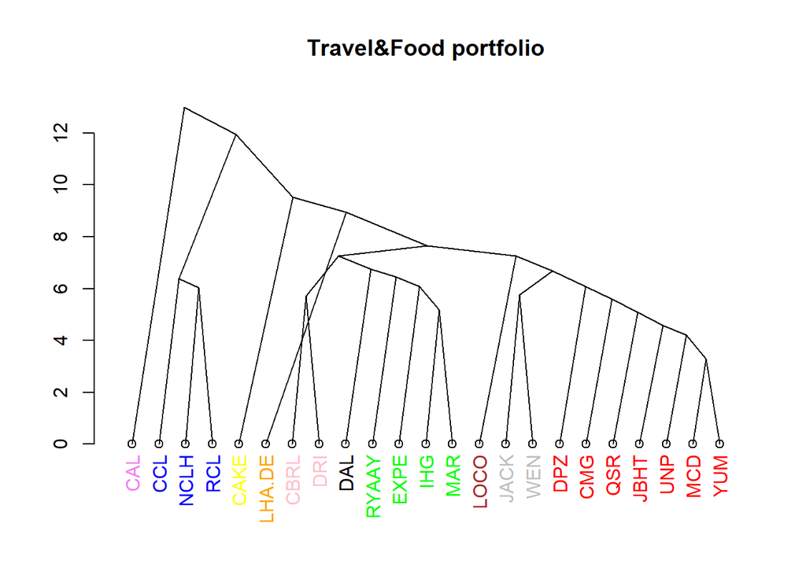

```r
#con la funzione as.dendrogram facciamo in modo da modificare la classe del cluster gerarchico in "dendrogramma".
  hcd <- as.dendrogram(hc.travrest)
  labelColors = c("red", "blue", "green", "orange", "violet", "black", "gray", "brown", "pink", "yellow") #creiamo il vettore dei colori da assegnare al cluster
cluster.travrest <- cutree(hc.travrest, 10) #scegliamo il numero dei cluster
  colorsLabel <- function(n) {
  if (is.leaf(n)) { #is.leaf individua tramite i nodi del dendrogramma un cluster
    a <- attributes(n) #creiamo un vettore vuoto
    labCol <- labelColors[cluster.travrest[which(names(cluster.travrest) == a$label)]]
    attr(n, "nodePar") <- c(a$nodePar, lab.col = labCol) #attribuiamo ad n un colore in base ai nodi (cluster)
  }
  n
  } #con questa funzione quindi assegniamo un colore dal vettore labelColors ad ogni cluster.

  clusDendro = dendrapply(hcd, colorsLabel) #con dendrapply quindi applichiamo all'oggetto di classe "dendrogram" un colore in base ai cluster tramite la funzione colLab creata in precedenza, che assegna un colore ad ogni livello

  plot(clusDendro, main = "Travel&Food portfolio", type = "triangle")
```

- Riportiamo i titoli nella matrice dei rendimenti seguendo l’ordine cluster:

```r
returns.hc1<- merge.xts(CAL, CCL, NCLH, RCL, CAKE, LHA.DE, CBRL, DRI, DAL, RYAAY, EXPE, IHG, MAR, LOCO, JACK, WEN, DPZ, CMG, QSR, JBHT, UNP, MCD, YUM)
returns.hc1 <-na.omit(returns.hc1)
colnames(returns.hc1) <- c("CAL","CCL", "NCLH", "RCL", "CAKE","LHA.DE","LOCO", "JACK", "WEN","DPZ", "CMG", "QSR", "JBHT", "UNP", "MCD", "YUM","CBRL", "DRI","DAL","RYAAY", "EXPE", "IHG", "MAR")
#redistribuiamo i pesi seguendo il cluster

wts_cluster1<- c(0.1,0.033,0.033,0.033,0.1,0.1,0.1,0.05,0.05,0.01428,0.01428,0.01428,0.01428,0.01428,0.01428,0.01428,0.05,0.05,0.1,0.025,0.025,0.025,0.025)
```

- Osserviamo la variazione di rendimento di portafoglio ottenuta:

```r
portfolio_returns_cluster1 <- Return.portfolio(R = returns.hc1, weights = wts_cluster1, wealth.index = TRUE)
comp_cluster <- merge.xts(portfolio_returns_cluster1, benchmark_returns_tr, portfolio_returns_tr)
colnames(comp_cluster) <- c("Travel&Food Portfolio cluster", "Benchmark", "Portafoglio equipesato")

# Grafico interattivo per confrontare le performance
dygraph(comp_cluster, main = "Travel&Food Portfolio Performance vs. Benchmark") %>%
  dyAxis("y", label = "Amount ($)") %>%
  dyOptions(colors = RColorBrewer::brewer.pal(4, "Set1"))
```

[interactive chart not shown]

- Come detto in precedenza, equidistribuire il capitale è un qualcosa di finanziariamente scorretto proprio perchè il mercato è fatto di titoli correlati ad altri titoli a loro volta correlati ad altri titoli (anche se appartenenti a settori diversi), dunque rappresenta una situazione “irreale”, ecco perchè non deve stupire che il rendimento del portafoglio equipesato sia maggiore di quello cluster. Grazie all’analisi cluster infatti, abbiamo ottenuto anzitutto un andamento reale di un portafoglio *veritiero*, il quale resta pressochè sempre al di sotto del proprio benchmark, a causa dello stato di fermo di tali settori in pandemia. Il benchmark inoltre, che rispetta sia le tendenze, sia le volontà di chi si affaccia sul mercato, non ha presentato eccessivi ribassi se non nelle fasi di chiusura. Nei periodi di normativa flessibile, il portafoglio cluster è stato al passo con il benchmark, pertanto l’analisi cluster si può ritenere, comunque, un successo.

# **Capitolo 3: Cluster utility**

Il clustering di serie temporali che descrive l’andamento dei prezzi dei titoli è un utile strumento a supporto della gestione degli investimenti. L’individuazione delle correlazioni tra titoli è infatti un principio base per la diversificazione del portafoglio.  
L’obiettivo della diversificazione è diminuire il rischio degli investimenti tramite la presenza in portafoglio di più attività finanziarie il cui andamento non è correlato.

Qui di seguito comporremo un portafoglio specifico per Mr. Eco e poi per Mr. Flight seguendo il metodo clustering tradizionale.

## *Metodo cluster tradizionale*

Dal pacchetto [PerformanceAnalytics](https://cran.r-project.org/web/packages/PerformanceAnalytics/PerformanceAnalytics.pdf),tramite la funzione *portfolio.spec*, è possibile costruire un portafoglio basato sul modello di Markovitz.

*Con il modello di Markovitz si costruisce un mondo “media-varianza” dove i rendimenti dei vari asset sono quindi distribuiti normalmente.*

Creiamo il nostro portafoglio fornendo in input specifiche precise.

**L’idea è quella di scegliere il portafoglio che a parità di rendimento abbia il minor rischio, ossia la miglior varianza.**

## **3.1** *Composizione portfolio risk objective* - Mr. Eco

*Componiamo un portafoglio green efficiente:

```r
#diamo in input alla funzione portfolio.spec gli asset (ovvero le colonne del data frame) del portafoglio green
pspec <- portfolio.spec(assets=colnames(green.returns[,1:25]), weight_seq=generatesequence())

#specifichiamo che il tipo di portafogli abbia il vincolo che la "somma dei pesi" sia pari a 1
  pspec <- add.constraint(portfolio = pspec, type = "weight_sum", min_sum = 0.99, max_sum = 1.01, enabled = TRUE)

  #specifichiamo i margini di distribuzione del capitale
  pspec <- add.constraint(portfolio = pspec, type = "box", min= 0.003, max = 0.500)

  #obiettivo dell'investitore razionale è MASSIMIZZARE IL RENDIMENTO E MINIMIZZARE IL RISCHIO
  pspec <- add.objective(portfolio = pspec, type = "return", name = "mean")
  pspec <- add.objective(portfolio=pspec,type="risk",name="StdDev")

  #ottimizziamo i pesi sulla base delle specifiche fornite per il nostro portafoglio
  opt<-optimize.portfolio(R=green.returns[,1:25],portfolio=pspec,optimize_method="random",trace=T)
```

```r
#estraiamo i pesi dalla funzione "opt"
  pesiOPT<-extractWeights(opt)
  pesiOPT
```

```
##  TSLA   ALB  NKLA  SEDG  ENPH   NIO  PLUG  CREE    ON  FSLR   RUN   NEE    AY
##  0.01  0.01  0.01  0.01  0.01  0.01  0.01  0.01  0.01  0.01  0.02  0.07  0.02
##    BL  CSIQ  FCEL  NOVA OEZVY   CMI VWDRY   JKS   CIG    DQ IBDRY GCTAY
##  0.01  0.01  0.01  0.01  0.28  0.39  0.02  0.01  0.01  0.01  0.01  0.01
```

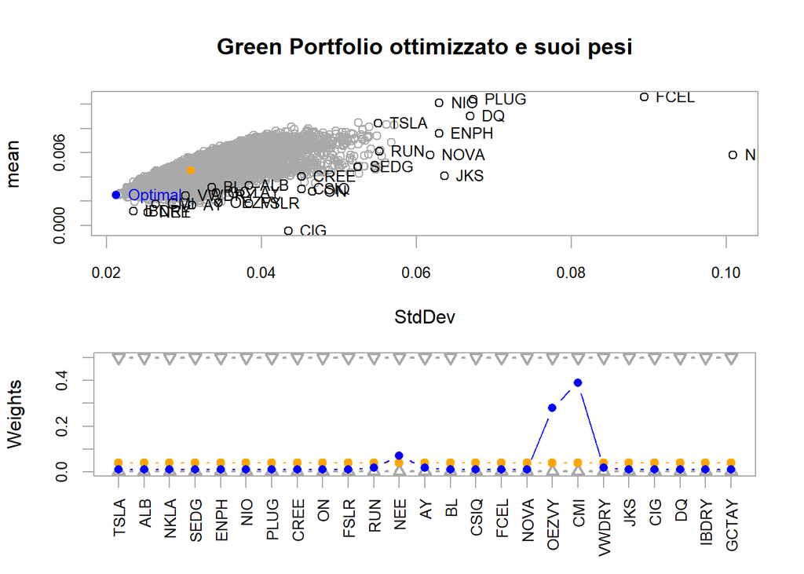

```r
#plottiamo la distribuzione
  plot(opt, return.col="mean", risk.col = "StdDev", chart.assets = T,
       main="Green Portfolio ottimizzato e suoi pesi")
```

- Confrontiamo il rendimento del portafoglio così ottenuto con il benchmark:

```r
#in input ai pesi andranno sostituiti i pesi ottenuti dalla funzione "opt"
portfolio_returns_green <- Return.portfolio(R=green.returns[,1:25], weights = pesiOPT, wealth.index = TRUE)
comp_green <- merge.xts(portfolio_returns_green, benchmark_returns_green)
colnames(comp_green) <- c("Portfolio", "Benchmark")
dygraph(comp_green, main = "Green Portfolio Markovitz-Performance vs. Benchmark") %>%
  dyAxis("y", label = "Amount ($)")
```

[interactive chart not shown]

- Il portafoglio così costruito, poichè è stata di base violata l’ipotesi di incorrelazione dei titoli (elemento necessario ai fini della diversificazione del portafoglio), assume un rendimento inizialmente pari e poi nettamente al di sotto del proprio indice. Lo stesso portafoglio inoltre, anche quando è in positivo, non registra particolari “impennate” poichè quello di Markovitz è un modello *prudente* che tutela l’investitore, mantenendo sempre contenuto il rischio collegato alle azioni.

## **3.2** *Composizione portfolio risk objective* - Mr. Flight

Così come per Mr. Eco, creiamo un Food&Travel Portfolio che non tenga conto della precendente analisi cluster e che risulti ottimizzato secondo il modello media-varianza.

```
##    UNP   JBHT    CCL   NCLH    RCL  RYAAY LHA.DE    CAL    DAL    IHG    MAR
##   0.01   0.20   0.01   0.01   0.01   0.02   0.01   0.01   0.07   0.01   0.01
##   EXPE    MCD    DPZ   JACK   LOCO    YUM   CBRL    CMG    DRI   CAKE    WEN
##   0.01   0.01   0.48   0.01   0.01   0.06   0.01   0.01   0.01   0.01   0.01
##    QSR
##   0.01
```

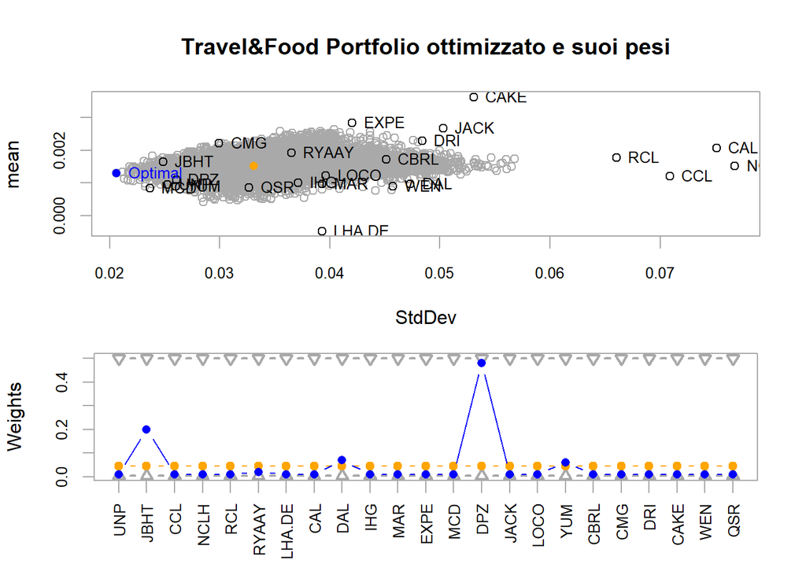

- Confrontiamo il portafoglio ottenuto col proprio indice di riferimento di mercato:

[interactive chart not shown]

- La prudenza insita nel modello di Markovitz gioca a favore di Mr.Flight e risulta in questo grafico interattivo ancor più significativa. Nonostante la tendenza del mercato (descritta dall’indice di riferimento) a sottostimare i settori che compongono il Travel&Food Portfolio, il modello riesce comunque a reggere meglio lo shock temporaneo di domanda e offerta negli ambiti finanziari di ristorazione e di logistica. Interessante la risposta del portafoglio al secondo lockdown (Ottobre 2020) che resta comunque in attivo nonostante le perdite, a differenza del picco in negativo subito nell’aprile 2020 (shock a cui il mercato era impreparato).

## **3.3** *Portfolio risk objective vs portfolio cluster*

- Componiamo ora il portafoglio risk objective basandoci sul cluster effettuato sulle serie temporali dei titoli. Il metodo è equivalente al precedente, avendo però come assets l’insieme ordinato dei titoli ottenuto dall’analisi cluster.
- *Clustering su serie storiche finanziarie* - GREEN PORTFOLIO

```r
#CON L INSIEME CLUSTER HC
 #in input alla funzione portoflio.returns viene assegnato l'insieme returns.hc, ovvero l'insieme ordinato secondo l'analisi cluster del portafoglio green.
 pspec <- portfolio.spec(assets=colnames(returns.hc), weight_seq=generatesequence())
  #specifichiamo che il portafoglio è di tipo "somma dei pesi" col vincolo che la loro somma sia pari a 1
  pspec <- add.constraint(portfolio = pspec, type = "weight_sum", min_sum = 0.99, max_sum = 1.01, enabled = TRUE)
  #specifichiamo i margini di distribuzione del capitale
  pspec <- add.constraint(portfolio = pspec, type = "box", min= 0.003, max = 0.500)
  #obiettivO dell'investitore razionale ? MASSIMIZZARE IL RENDIMENTO E MINIMIZZARE IL RISCHIO
  pspec <- add.objective(portfolio = pspec, type = "return", name = "mean")
  pspec <- add.objective(portfolio=pspec,type="risk",name="StdDev")
  #ottimizziamo i pesi sulla base delle specifiche fornite per il nostro portafoglio
  opt_CLU<-optimize.portfolio(R=returns.hc,portfolio=pspec,optimize_method="random",trace=T)
  pesiOPT_CLU<-extractWeights(opt_CLU)
  #estraiamo i pesi dalla funzione per utilizzarli nell'analisi cluster
portfolio_returns_clu <- Return.portfolio(R=returns.hc, weights = pesiOPT_CLU, wealth.index = TRUE)
```

- *Confrontiamo i rendimenti ottenuti dai due diversi tipi di cluster:*

[interactive chart not shown]

- Dal grafico si evince che seguendo il modello di Markovitz applicato all’insieme ordinato di dati secondo il cluster, il rendimento del portafoglio è lievemente superiore, ma nettamente inferiore al rendimento assicurato dal portafoglio costruito esclusivamente basandosi sull’analisi cluster (traccia viola), che vede più del quadruplo del rendimento!
- *Clustering su serie storiche finanziarie* - TRAVEL&FOOD PORTFOLIO

```r
#CON L INSIEME CLUSTER HC
 #in input alla funzione portoflio.returns viene assegnato l'insieme returns.hc, ovvero l'insieme ordinato secondo l'analisi cluster del portafoglio trav.rest.
pspec1 <- portfolio.spec(assets=colnames(returns.hc1), weight_seq=generatesequence())
  #specifichiamo che il portafoglio è di tipo "somma dei pesi" col vincolo che la loro somma sia pari a 1
  pspec1 <- add.constraint(portfolio = pspec1, type = "weight_sum", min_sum = 0.99, max_sum = 1.01, enabled = TRUE)
  #specifichiamo i margini di distribuzione del capitale
  pspec1 <- add.constraint(portfolio = pspec1, type = "box", min= 0.003, max = 0.500)
  #obiettivO dell'investitore razionale ? MASSIMIZZARE IL RENDIMENTO E MINIMIZZARE IL RISCHIO
  pspec1 <- add.objective(portfolio = pspec1, type = "return", name = "mean")
  pspec1 <- add.objective(portfolio=pspec1,type="risk",name="StdDev")
  #ottimizziamo i pesi sulla base delle specifiche fornite per il nostro portafoglio
  opt1_CLU<-optimize.portfolio(R=returns.hc1,portfolio=pspec1,optimize_method="random",trace=T)
pesiOPT1_CLU<-extractWeights(opt1_CLU)
  #estraiamo i pesi dalla funzione per utilizzarli nell'analisi cluster
portfolio_returns_clu1<- Return.portfolio(R=returns.hc1, weights = pesiOPT1_CLU, wealth.index = TRUE)
```

- *Confrontiamo i rendimenti ottenuti dai due diversi tipi di cluster:*

[interactive chart not shown]

- Con il seguente andamento di rendimenti, si evince che accompagnando ad un portafoglio markovitziano diversificato (ma nemmeno troppo), un’analisi cluster, si possono ottenere rendimenti al meglio delle possibilità del solo modello media-varianza solo quando il mercato ha già registrato una certa tendenza: da Ottobre 2020 in poi, il portafoglio di Marvovitz costruito sull’analisi cluster è più fruttoso poichè reagisce più rapidamente agli shock finanziari.  
  Si noti se Mr. Flight avesse deciso di investire a seguito della sola analisi cluster (traccia viola), avrebbe rinunciato a veder quasi raddoppiato il suo patrimonio.

## **CONSIDERAZIONI**

La principale difficoltà è legata alla definizione della misura di similarità. L’analisi cluster può essere uno strumento utile alla gestione del portafoglio, a differenza del clustering di generiche serie temporali, se vengono fornite delle misure quantitative della somiglianza, tra singoli titoli o tra titoli appartenenti ad un cluster, in modo da dare un’indicazione misurabile all’analista.

Il portafoglio di Mr. Eco risente maggiormente dell’efficacia dell’analisi cluster proprio perchè il fatto stesso di essere un portafoglio indicizzato è una misura quantitativa della somiglianza molto forte. Nel momento stesso in cui viene condizionato ad un altro modello che promuove la dissimilarità, perde di efficacia.

Non appena si inizia a diversificare il portafoglio, come nel caso di Mr. Flight (composto da azioni dei settori di ristorazione e trasporti), l’effetto dell’analisi cluster inizia a scemare a favore dell’analisi Markobvitziana basata sull’incorrelazione dei titoli. Tuttavia l’analisi cluster riesce comunque a dare il suo contributo a lungo termine anche nel modello media-varianza.

# **Appendice - Composizione random portfolio**

In questo project-work sono stati presi in considerazione portafogli settoriali al fine di riscontrare evidenze a favore dell’utilizzo dell’analisi cluster in aggiunta al noto schema Lagrangiano di minimi vincolati nel processo di composizione ottimale di portafogli di investitori razionali.  
Un portafoglio composto da titoli “simili” ha permesso di riscontrare l’efficacia dell’analisi cluster in maniera *forte*.

Un portafoglio infatti, è ben diversificato non solo se alla base c’è una distribuzione “obiettiva” di capitale, ma anche se è abbastanza vario da contenere titoli che rispondano in maniera differente alla stessa causa, per *sopportare* meglio gli shock finanziari.

Dunque, generalemente, un portafoglio è formato da titoli appartenenti a categorie diverse. Qui di seguito ne verrà generato uno composto da titoli scelti dai dataset in modo randomizzato, seguendo quella che può essere la tendenza del mercato e le volontà dell’investitore.

- Andiamo ad incrementare la lista di ticker a nostra disposizione con titoli appartenenti ad altre categorie.
- TECH PORTFOLIO

```r
daily_returns("AAPL", 2020) #Apple
daily_returns("SNE", 2020) #Sony entertainment network
daily_returns("MSFT", 2020) #Microsoft
daily_returns("GOOG", 2020) #Google
daily_returns("INTC", 2020) #Intel Corporation
daily_returns("IBM", 2020) #IBM
daily_returns("FB", 2020) #Facebook
daily_returns("ORCL", 2020) #Oracle
daily_returns("TCEHY", 2020) #Tencent Holdings Ltd
daily_returns("SAP", 2020) #SAP
daily_returns("AMZN", 2020) #Amazon
daily_returns("NVDA", 2020) #Nvidia
daily_returns("LRCX", 2020) #Lam Research Corp
daily_returns("PANW", 2020) #Palo Alto Network Inc.
daily_returns("CHKP", 2020) #Check Point software Technologies
daily_returns("MELI", 2020) #Mercadolibre Inc.
daily_returns("DOCU", 2020) #DocuSign Inc.
daily_returns("UA", 2020) #Under Armour Inc.

tech.returns <- merge.xts(AAPL, SNE, MSFT, GOOG, INTC, IBM, FB, ORCL, TCEHY, SAP, AMZN, NVDA, LRCX, PANW, CHKP, MELI, DOCU,UA)
colnames(tech.returns) <- c("AAPL", "SNE", "MSFT", "GOOG", "INTC", "IBM", "FB", "ORCL", "TCEHY", "SAP", "AMZN", "NVDA", "LRCX", "PANW", "CHKP", "MELI", "DOCU", "UA")
```

- PHARMA PORTFOLIO

```r
daily_returns("BIIB", 2020) #Biogen Inc.
daily_returns("AMGN", 2020) #Amagen Inc.
daily_returns("GILD", 2020) #Gilead Sciences Inc.
daily_returns("REGN", 2020) #Regeneron Pharmaceuticals Inc.
daily_returns("CRSP", 2020) #CRISPR Therapeutics AG
daily_returns("SNY", 2020) #Sanofy SA
daily_returns("LLY", 2020) #Eli Lilly and Co.
daily_returns("NVS", 2020) #Novartis AG
daily_returns("RHHBY", 2020) #Roche Holding AG
daily_returns("PFE", 2020) #Pfizer Inc.
daily_returns("MRNA", 2020) #Moderna Inc.
daily_returns("JNJ", 2020) #Johnson & Johnson
daily_returns("EXEL", 2020) #Exelixis Inc.
daily_returns("VRTX", 2020) #Vertex Pharmaceuticals Inc.
daily_returns("ABBV", 2020) #Abbvie Inc.

pharma.returns <- merge.xts(BIIB, AMGN, GILD, REGN, CRSP, SNY, LLY, NVS, RHHBY, PFE, MRNA, JNJ, EXEL, VRTX, ABBV)
colnames(pharma.returns) <- c("BIIB", "AMGN", "GILD", "REGN", "CRSP", "SNY", "LLY", "NVS", "RHHBY", "PFE", "MRNA", "JNJ", "EXEL", "VRTX", "ABBV")
```

Una volta uniti i dataframe di ogni gruppo di ticker in unico dataset “all.returns”, è sufficiente implementare una funzione che riceve in input “all.returns” e il numero di azioni che si vuole inserire per ogni categoria proposta:  
* *g* richiede l’inserimento del numero di azioni *green* desiderato;  
* *r* richiede l’inserimento del numero di azioni *rest* desiderato;  
* *t* richiede l’inserimento del numero di azioni *tech* desiderato;  
* *tr* richiede l’inserimento del numero di azioni *travel* desiderato;  
* *ph* richiede l’inserimento del numero di azioni *pharma* desiderato;

```r
#effettuiamo un concatenamento tra colonne
all.returns=cbind(green.returns, rest.returns, tech.returns, travel.returns, pharma.returns)
all.returns<-as.matrix(all.returns)
port_random<-function(all.returns,g,r,t,tr,ph){
  #selezioniamo 5 api randomizzate da ogni sotto insieme returns
  group1<-green.returns[,sample(1:ncol(green.returns),g,replace=FALSE)]
  group2<-rest.returns[,sample(1:ncol(rest.returns),r,replace=FALSE)]
  group3<-tech.returns[,sample(1:ncol(tech.returns),t,replace=FALSE)]
  group4<-travel.returns[,sample(1:ncol(travel.returns),tr,replace=FALSE)]
  group5<-pharma.returns[,sample(1:ncol(pharma.returns),ph,replace=FALSE)]
  final.returns<-cbind(group1,group2,group3,group4,group5)
  final.returns[is.na(final.returns)]<-0
  return(final.returns)

}
```

Un investitore che guarda al futuro, ad esempio, potrebbe voler investire principalmente in azioni green, tech e pharma (volendo seguire la tendenza dei mercati in vista del commercio di vaccini antiCovid) e meno sui settori di ristorazione poichè non si prospetta un rapido ritorno alla normalità:

```r
random=port_random(all.returns,8,3,7,3,6)
```

Random Portfolio Composition

| QCLN | SEDG | ENPH | TSLA | DQ | CSIQ | CMI | IBDRY | CBRL | LOCO | CAKE | PANW | MSFT | UA | FB | SNE | MELI | TCEHY | NCLH | CCL | LHA.DE | PFE | ABBV | EXEL | REGN | JNJ | BIIB |
| --- | --- | --- | --- | --- | --- | --- | --- | --- | --- | --- | --- | --- | --- | --- | --- | --- | --- | --- | --- | --- | --- | --- | --- | --- | --- | --- |
| 0.001977106 | 0.005598654 | -0.001704124 | 0.029633186 | -0.009639869 | -0.031971625 | -0.0139974065 | -0.0065486740 | 0.005498741 | -0.0013297872 | -0.005645464 | 0.006032021 | -0.012451748 | 0.0015592516 | -0.005291262 | -0.014190501 | -0.003916836 | -0.017040962 | -0.020907767 | -0.027674996 | -0.0653477218 | -0.005365372 | -0.009492026 | -0.036806342 | -0.011222718 | -0.0115777925 | -0.0115211532 |
| -0.001973204 | -0.026860716 | 0.012632263 | 0.019254668 | -0.011019284 | 0.023853258 | -0.0151574193 | -0.0009766159 | 0.005018442 | 0.0193075899 | 0.024774180 | 0.014482933 | 0.002584890 | -0.0467046705 | 0.018833603 | 0.015129245 | -0.002056598 | -0.005302812 | -0.013888872 | -0.030266534 | -0.0160359205 | -0.001284241 | 0.007891816 | 0.032333862 | 0.006988802 | -0.0012474517 | -0.0001031425 |
| 0.010280773 | 0.021680258 | 0.011126096 | 0.038800516 | -0.009099350 | 0.001792159 | 0.0007465479 | -0.0207721701 | -0.008578256 | -0.0169823645 | -0.008310200 | 0.005743794 | -0.009117869 | 0.0119759928 | 0.002163650 | 0.015771900 | 0.030417958 | 0.020709391 | 0.002992993 | 0.003100381 | 0.0016297262 | -0.003343686 | -0.005704697 | 0.063781382 | 0.003739213 | 0.0061067157 | -0.0025101815 |
| 0.010958878 | 0.023283259 | 0.033677893 | 0.049204848 | 0.019115442 | 0.009391726 | 0.0005165338 | -0.0082355179 | 0.011881022 | 0.0019933555 | 0.006602350 | -0.012704817 | 0.015928414 | -0.0231307154 | 0.010138003 | 0.003703732 | 0.013504003 | -0.002611459 | 0.010531841 | 0.004739387 | 0.0113895216 | 0.008000013 | 0.007087473 | 0.014454015 | 0.024897510 | -0.0001378288 | 0.0088593472 |
| -0.002709933 | -0.013632930 | 0.019032258 | -0.021945005 | 0.023721957 | 0.014178068 | -0.0047606705 | 0.0232080028 | -0.011358715 | 0.0000000000 | 0.002522708 | 0.006287463 | 0.012492876 | -0.0209250551 | 0.014310947 | 0.008089696 | 0.020507058 | 0.016716991 | 0.008511395 | 0.009023814 | 0.0398970399 | -0.004352205 | 0.007707783 | -0.016886648 | 0.002745641 | 0.0029662696 | 0.0056037175 |
| -0.003105644 | 0.017325278 | -0.029123140 | -0.006627343 | 0.007005569 | -0.014853649 | -0.0120448688 | 0.0017544243 | 0.021880908 | -0.0079575597 | -0.007549181 | -0.009164044 | -0.004627055 | -0.0005624859 | -0.001099427 | -0.002393327 | 0.035657360 | 0.018819379 | -0.001722391 | -0.007113838 | -0.0213490099 | 0.015428082 | -0.012748140 | -0.016639775 | -0.005371990 | -0.0022697560 | 0.0075094193 |
| 0.031152602 | -0.013777220 | 0.003912651 | 0.097689044 | 0.060292544 | 0.022616409 | 0.0061833975 | 0.0070053289 | 0.001136935 | -0.0066844920 | -0.001014092 | 0.012822143 | 0.012024394 | 0.0151942037 | 0.017655719 | 0.011007592 | 0.032293715 | 0.017110686 | -0.002070376 | 0.010440117 | -0.0199177996 | -0.002025894 | -0.006063247 | 0.008187718 | -0.006502218 | 0.0044119722 | -0.0088024549 |
| 0.007930543 | 0.009119082 | -0.019162065 | 0.024882826 | -0.008580081 | 0.016912490 | -0.0005219242 | -0.0002484673 | 0.023911677 | 0.0006729475 | 0.004060898 | -0.003818687 | -0.007043214 | 0.0399112506 | -0.012843071 | 0.011585734 | -0.056475142 | -0.017587531 | 0.001037379 | 0.017220445 | -0.0109677419 | 0.016746993 | 0.009846518 | 0.063887443 | 0.022933001 | 0.0056280067 | 0.0172507897 |
| -0.003746796 | -0.003941511 | -0.001324536 | -0.036102050 | -0.065501442 | -0.007249467 | 0.0012183012 | 0.0233597494 | 0.002095024 | -0.0047074647 | -0.007077958 | 0.002916654 | 0.006476380 | 0.0074626866 | 0.009540747 | -0.012005009 | 0.012130558 | -0.004281060 | -0.006217634 | 0.004580709 | -0.0006523157 | 0.014973862 | 0.012018276 | 0.038167939 | 0.008074932 | 0.0033442515 | -0.0196675418 |

Affidandosi al pacchetto [PerformanceAnalytics](https://cran.r-project.org/web/packages/PerformanceAnalytics/PerformanceAnalytics.pdf) precendentemente utilizzato, inoltre l’investitore, potrebbe comporre il portafoglio in base al proprio grado di avversione al rischio ed avere così un’idea di come suddividere il proprio capitale.

Qui di seguito, una possibile ripartizione dei pesi su capitale unitario da parte di un investitore razionale, e dunque che persegue l’obiettivo, a parità di rendimento, di minimizzare il rischio:

```
##   QCLN   SEDG   ENPH   TSLA     DQ   CSIQ    CMI  IBDRY   CBRL   LOCO   CAKE
##   0.01   0.01   0.01   0.01   0.01   0.01   0.01   0.01   0.01   0.01   0.01
##   PANW   MSFT     UA     FB    SNE   MELI  TCEHY   NCLH    CCL LHA.DE    PFE
##   0.01   0.01   0.01   0.02   0.23   0.01   0.02   0.01   0.01   0.01   0.01
##   ABBV   EXEL   REGN    JNJ   BIIB
##   0.01   0.01   0.02   0.50   0.01
```

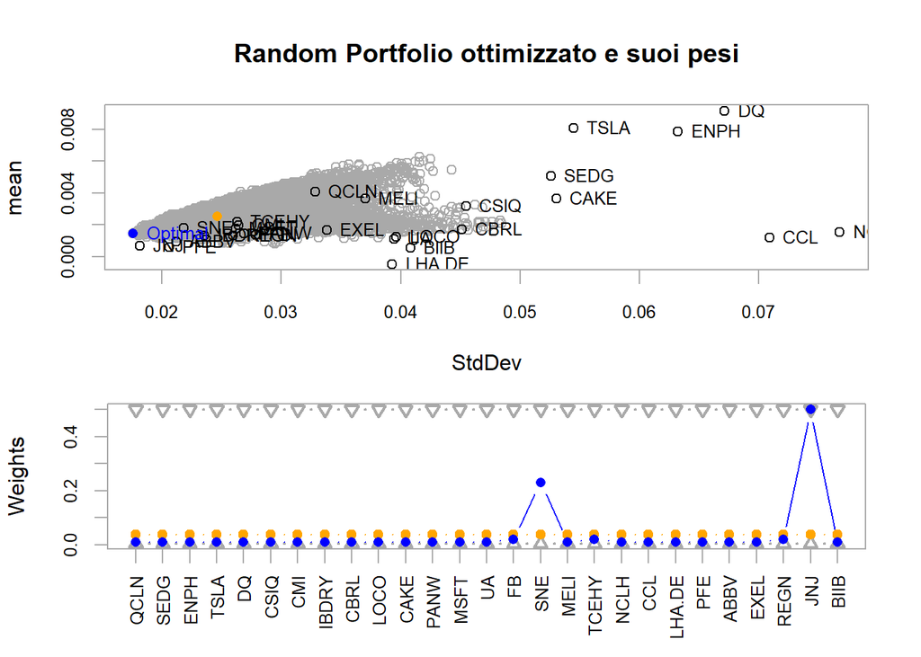

- Effettuiamo un’analisi cluster:

```r
random.c <- random[,1:27]
random.t <- t(random.c)
manatthan2 <- dist(random.t, method= "manhattan", diag=F, upper=F)
random.cluster<- hclust(manatthan2, method = "average")
print(random.cluster)
```

```
##
## Call:
## hclust(d = manatthan2, method = "average")
##
## Cluster method   : average
## Distance         : manhattan
## Number of objects: 27
```

- Con il dendrogramma otteniamo un’idea di quelle che sono le correlazioni:

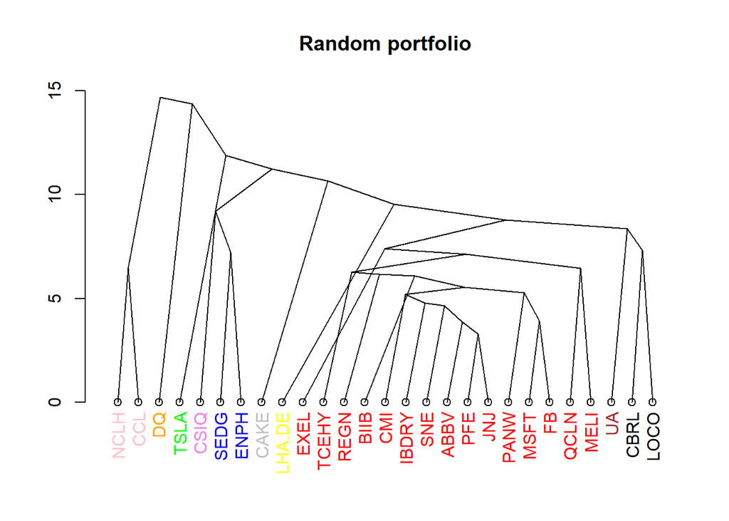

- Componiamo il portafoglio anche con gli assets ordinati a seguito dell’analisi cluster, generando anche qui dei pesi:

```
##   NCLH    CCL     DQ   TSLA   SEDG   ENPH LHA.DE   QLCN   CSIQ   MELI   EXEL
##   0.01   0.01   0.01   0.01   0.01   0.01   0.01   0.01   0.01   0.01   0.01
##   REGN   BIIB  TCEHY    CMI  IBDRY    SNE   ABBV    PFE    JNJ   PANW   MSFT
##   0.01   0.01   0.01   0.02   0.01   0.22   0.01   0.01   0.46   0.01   0.01
##     FB   CAKE     UA   CBRL   LOCO
##   0.01   0.01   0.01   0.02   0.07
```

- Confrontiamo i rendimenti ottenuti dai diversi ordinamenti del dataset:

[interactive chart not shown]

Nel periodo che va da fine Settembre 2020 a metà Ottobre 2020 si assiste ad un cambio di tendenza dei due portafogli: il portafoglio ottenuto dalla composizione di Markovitz sopporta il periodo crisi,e solo al protrarsi della situazione (dopo 10 mesi di trading circa) apporta sensibili migliorie al portafoglio (soprattutto settori tech e pharma). L’analisi cluster si dimostra, dopo ottobre 2020 inadeguata, ma ciò non deve stupire poichè è dalla fine del 2020 che i titoli che compongono il portafoglio random si diversificano maggiormente (il settore pharma impegnato nella ricerca del vaccino contro travel e food che continuano a crollare). Per il periodo precendente a Ottobre 2020 l’analisi cluster non si è mostrata particolarmente inefficace rispetto a Markovitz, a riprova del fatto che il concetto di “gruppo” è di difficile interpretazione e che da Febbraio 2020 tutti i settori erano accomunati dal fattore “covid” che li ha resi “simili” a livello finanziario.

# **RIESAMINAZIONE SCENARI**

Questo studio ha dunque riscontrato:  
- come il modello di Markovitz tenda a “resistere” agli shock finanziari temporanei, con lo svantaggio di stagnare i rendimenti per tenere basso il rischio;  
- come un cluster fatto appropriatamente con un sufficiente grado di similarità tra titoli per determitarne i pesi del portafoglio, riesca a rendere redditizia in tempi più veloci una tendenza di mercato, come lo è stata quella verso il green, sfruttando dunque al meglio uno shock finanziario, o un repentino cambio di domanda;  
- come un’analisi cluster abbinata alla creazione di un portafoglio media-varianza che presenta un certo grado di similarità (come il Travel&Food Portfolio), riesca ad apportare migliorie all’allocazione dei pesi all’interno del portafoglio;  
- che la stessa efficienza non viene riscontrata applicando Markovitz ad un portafoglio uni-indicizzato e questo perchè è un modello prudente che non “crede” ai repentini cambi di mercato e di conseguenza non valorizza tendenze che non sono ancora stabili nelle dinamiche dei mercati finanziari;  
- che la razionalità investitiva non salvaguarda dalle perdite, dunque quando si osserva una nuova tendenza di mercato e si “crede” in quell’idea tanto vale andare contro il modello di media-varianza e creare un portafoglio indicizzato avvalendosi di una semplice ma super efficace analisi cluster.